# Self-Driving Car Engineer Nanodegree

## Project: Build a Traffic Sign Recognition Classifier

In this notebook, a template is provided for you to implement your functionality in stages, which is required to successfully complete this project. If additional code is required that cannot be included in the notebook, be sure that the Python code is successfully imported and included in your submission if necessary.

> **Note**: Once you have completed all of the code implementations, you need to finalize your work by exporting the iPython Notebook as an HTML document. Before exporting the notebook to html, all of the code cells need to have been run so that reviewers can see the final implementation and output. You can then export the notebook by using the menu above and navigating to \n", "**File -> Download as -> HTML (.html)**. Include the finished document along with this notebook as your submission.

In addition to implementing code, there is a writeup to complete. The writeup should be completed in a separate file, which can be either a markdown file or a pdf document. There is a [write up template](https://github.com/udacity/CarND-Traffic-Sign-Classifier-Project/blob/master/writeup_template.md) that can be used to guide the writing process. Completing the code template and writeup template will cover all of the [rubric points](https://review.udacity.com/#!/rubrics/481/view) for this project.

The [rubric](https://review.udacity.com/#!/rubrics/481/view) contains "Stand Out Suggestions" for enhancing the project beyond the minimum requirements. The stand out suggestions are optional. If you decide to pursue the "stand out suggestions", you can include the code in this Ipython notebook and also discuss the results in the writeup file.

> **Note:** Code and Markdown cells can be executed using the **Shift + Enter** keyboard shortcut. In addition, Markdown cells can be edited by typically double-clicking the cell to enter edit mode.

```python
#imports
import pickle
import csv
import matplotlib.pyplot as plt
import numpy as np
from ipywidgets import interact
from cycler import cycler
from collections import Counter
from sklearn.utils import shuffle
from PIL import Image, ImageOps


import tensorflow as tf
tf.reset_default_graph()
saved_model_path = './lenet.ckpt'
```

## Step 0: Load The Data

```python
# Load pickled data
training_file = '../traffic-signs-data/train.p'
validation_file='../traffic-signs-data/valid.p'
testing_file = '../traffic-signs-data/test.p'

with open(training_file, mode='rb') as f:
    train = pickle.load(f)
with open(validation_file, mode='rb') as f:
    valid = pickle.load(f)
with open(testing_file, mode='rb') as f:
    test = pickle.load(f)

X_train, y_train = train['features'], train['labels']
X_valid, y_valid = valid['features'], valid['labels']
X_test, y_test = test['features'], test['labels']
```

## Step 1: Dataset Summary & Exploration

The pickled data is a dictionary with 4 key/value pairs:

- `'features'` is a 4D array containing raw pixel data of the traffic sign images, (num examples, width, height, channels).
- `'labels'` is a 1D array containing the label/class id of the traffic sign. The file `signnames.csv` contains id -> name mappings for each id.
- `'sizes'` is a list containing tuples, (width, height) representing the original width and height the image.
- `'coords'` is a list containing tuples, (x1, y1, x2, y2) representing coordinates of a bounding box around the sign in the image. **THESE COORDINATES ASSUME THE ORIGINAL IMAGE. THE PICKLED DATA CONTAINS RESIZED VERSIONS (32 by 32) OF THESE IMAGES**

Complete the basic data summary below. Use python, numpy and/or pandas methods to calculate the data summary rather than hard coding the results. For example, the [pandas shape method](http://pandas.pydata.org/pandas-docs/stable/generated/pandas.DataFrame.shape.html) might be useful for calculating some of the summary results.

### Provide a Basic Summary of the Data Set Using Python, Numpy and/or Pandas

```python
# Number of training examples
n_train = X_train.shape[0]

# Number of validation examples
n_validation = X_valid.shape[0]

# Number of testing examples.
n_test = X_test.shape[0]

# What's the shape of an traffic sign image?
image_shape = X_train.shape[1:]

# How many unique classes/labels there are in the dataset.
n_classes = len(set(y_train))

print("Number of training examples =", n_train)
print("Number of validation examples =", n_validation)
print("Number of testing examples =", n_test)
print("Image data shape =", image_shape)
print("Number of classes =", n_classes)
```

```
Number of training examples = 34799
Number of validation examples = 4410
Number of testing examples = 12630
Image data shape = (32, 32, 3)
Number of classes = 43
```

### Include an exploratory visualization of the dataset

Visualize the German Traffic Signs Dataset using the pickled file(s). This is open ended, suggestions include: plotting traffic sign images, plotting the count of each sign, etc.

The [Matplotlib](http://matplotlib.org/) [examples](http://matplotlib.org/examples/index.html) and [gallery](http://matplotlib.org/gallery.html) pages are a great resource for doing visualizations in Python.

**NOTE:** It's recommended you start with something simple first. If you wish to do more, come back to it after you've completed the rest of the sections. It can be interesting to look at the distribution of classes in the training, validation and test set. Is the distribution the same? Are there more examples of some classes than others?

```python
#Traffic sign name dictionary
traffic_name_dict = {}
with open('signnames.csv') as csvfile:
    reader = csv.DictReader(csvfile)
    for row in reader:
        traffic_name_dict[int(row['ClassId'])] = row['SignName']
```

```python
# Visualizations will be shown in the notebook.
%matplotlib inline
```

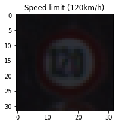

```python
#Show random images from the training data set
def browse_images(images,labels,sample_no,random=True):
    img_idxs = range(0, images.shape[0])
    if random:
        img_idxs = np.random.choice(images.shape[0], sample_no)
    def view_image(i=0):
        idx = img_idxs[i]
        plt.imshow(images[idx])
        plt.title(traffic_name_dict[labels[idx]])
    interact(view_image, i=(0, sample_no-1))

browse_images(X_train, y_train, 200)
```

```python
#Color blind friendly color cycle for matplotlib
plt.rc('axes', prop_cycle=(cycler('color', ['#377eb8', '#ff7f00', '#4daf4a',
                  '#f781bf', '#a65628', '#984ea3',
                  '#999999', '#e41a1c', '#dede00'])))
```

```python
#Display distribution of classes in each data set
def plot_distribution_of_dataset_labels(datasets, legends):
    legend = []
    for dataset, label in zip(datasets, legends):
        counter = Counter(dataset)

        #normalize counts of labels
        factor=1.0/sum(counter.values())
        for k in counter:
          counter[k] = counter[k]*factor

        lists = sorted(counter.items())
        x, y = zip(*lists)
        plot_line, = plt.plot(x, y, label=label)
        legend.append(plot_line)
    plt.legend(handles=legend)
    plt.title("Distribution of data set labels")
    plt.show()
```

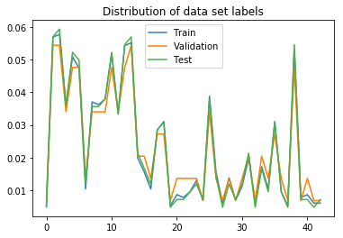

```python
plot_distribution_of_dataset_labels([y_train,y_valid,y_test], ["Train","Validation","Test"])
```

## Step 2: Design and Test a Model Architecture

Design and implement a deep learning model that learns to recognize traffic signs. Train and test your model on the [German Traffic Sign Dataset](http://benchmark.ini.rub.de/?section=gtsrb&subsection=dataset).

The LeNet-5 implementation shown in the classroom at the end of the CNN lesson is a solid starting point. You'll have to change the number of classes and possibly the preprocessing, but aside from that it's plug and play!

With the LeNet-5 solution from the lecture, you should expect a validation set accuracy of about 0.89. To meet specifications, the validation set accuracy will need to be at least 0.93. It is possible to get an even higher accuracy, but 0.93 is the minimum for a successful project submission.

There are various aspects to consider when thinking about this problem:

- Neural network architecture (is the network over or underfitting?)
- Play around preprocessing techniques (normalization, rgb to grayscale, etc)
- Number of examples per label (some have more than others).
- Generate fake data.

Here is an example of a [published baseline model on this problem](http://yann.lecun.com/exdb/publis/pdf/sermanet-ijcnn-11.pdf). It's not required to be familiar with the approach used in the paper but, it's good practice to try to read papers like these.

## Increase data set with fake data

Increase the train data set 5 times by adding permutated fake images

```python
from skimage import transform, filters, exposure, img_as_ubyte
import warnings
import random

PIXELS = image_shape[0]
PERMUTATION_NO = 4

def generate_fake_images(X_data, y_data):
    '''
    Fake data generator
    rotate all images in a given batch between -10 and 10 degrees
    random translations between -3 and 3 pixels in all directions.
    random zooms between 0.9 and 1.2.
    random shearing between -15 and 15 degrees.
    '''

    # set empty copy to hold augmented images so that we don't overwrite
    X_fake = np.empty(shape = (X_data.shape[0]*PERMUTATION_NO, X_data.shape[1], X_data.shape[2], X_data.shape[3]),
                      dtype='uint8')
    Y_fake = np.empty(shape = (y_data.shape[0]*PERMUTATION_NO), dtype='uint8')


    # images in the batch do the augmentation
    count = 0
    for i in range(X_data.shape[0]):

        image = X_data[i]

        for j in range(PERMUTATION_NO):
            # random rotations betweein -10 and 10 degrees
            dorotate = random.randint(-10,10)

            # random translations
            trans_1 = random.randint(-3,3)
            trans_2 = random.randint(-3,3)

            # random zooms
            zoom = random.uniform(0.9, 1.2)

            # shearing
            shear_deg = random.uniform(-15, 15)

            # set the transform parameters for skimage.transform.warp
            # have to shift to center and then shift back after transformation otherwise
            # rotations will make image go out of frame
            center_shift   = np.array((PIXELS, PIXELS)) / 2. - 0.5
            tform_center   = transform.SimilarityTransform(translation=-center_shift)
            tform_uncenter = transform.SimilarityTransform(translation=center_shift)

            tform_aug = transform.AffineTransform(rotation = np.deg2rad(dorotate),
                                                  scale =(1/zoom, 1/zoom),
                                                  shear = np.deg2rad(shear_deg),
                                                  translation = (trans_1, trans_2))

            tform = tform_center + tform_aug + tform_uncenter

            with warnings.catch_warnings():
                warnings.simplefilter("ignore")
                for k in range(image.shape[2]):
                    X_fake[count][...,k] = img_as_ubyte(transform.warp(image[...,k], tform,
                                                          output_shape = (PIXELS, PIXELS)))

            Y_fake[count] = y_data[i]
            count += 1
    return X_fake, Y_fake
```

```python
fake_x, fake_y = generate_fake_images(X_train, y_train)
```

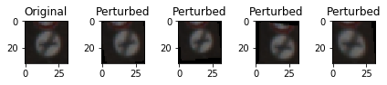

```python
fig, axes = plt.subplots(nrows=1, ncols=5)
fig.tight_layout()

ax = axes.ravel()

ax[0].imshow(X_train[0])
ax[0].set_title("Original")

for i in range(0,4):
    ax[i+1].imshow(fake_x[i])
    ax[i+1].set_title("Perturbed")
```

```python
X_train = np.append(X_train, fake_x, axis=0)
y_train = np.append(y_train, fake_y, axis=0)
#Reshuffle all images
X_train, y_train = shuffle(X_train, y_train)
print('New X_train shape', X_train.shape)
print('New y_train shape', y_train.shape)
```

```
New X_train shape (173995, 32, 32, 3)
New y_train shape (173995,)
```

### Pre-process the Data Set (normalization, grayscale, etc.)

Minimally, the image data should be normalized so that the data has mean zero and equal variance. For image data, `(pixel - 128)/ 128` is a quick way to approximately normalize the data and can be used in this project.

Other pre-processing steps are optional. You can try different techniques to see if it improves performance.

Use the code cell (or multiple code cells, if necessary) to implement the first step of your project.

```python
#Preprocess images - image standardization
def normalize_image_pil(image_array):
    image = Image.fromarray(image_array)
    image = ImageOps.autocontrast(image, 2)
    return np.array(image)
```

```python
normalize_image = normalize_image_pil
```

```python
X_train_n = list(map(normalize_image, X_train))
X_train_n = np.asarray(X_train_n)

X_valid_n = list(map(normalize_image, X_valid))
X_valid_n = np.asarray(X_valid_n)

X_test_n = list(map(normalize_image, X_test))
X_test_n = np.asarray(X_test_n)
```

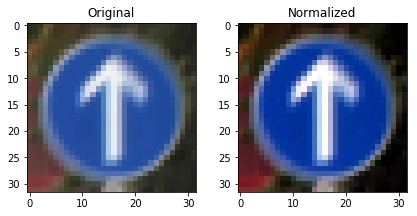

```python
idx = 102

fig, axes = plt.subplots(nrows=1, ncols=2)
fig.tight_layout()

ax = axes.ravel()

ax[0].imshow(X_train[idx])
ax[0].set_title("Original")

ax[1].imshow(X_train_n[idx])
ax[1].set_title("Normalized")
```

```python
#Preprocess images -  convert to grayscale
def rgb2gray_pil(image_array):
    image = Image.fromarray(image_array)
    return np.array(ImageOps.grayscale(image))
```

```python
X_train_n = np.asarray(list(map(rgb2gray_pil, X_train_n)))
X_valid_n = np.asarray(list(map(rgb2gray_pil, X_valid_n)))
X_test_n = np.asarray(list(map(rgb2gray_pil, X_test_n)))

X_train_n = np.expand_dims(X_train_n,axis=3)
X_valid_n = np.expand_dims(X_valid_n,axis=3)
X_test_n = np.expand_dims(X_test_n,axis=3)
```

```python
idx = 102

fig, axes = plt.subplots(nrows=1, ncols=2)
fig.tight_layout()

ax = axes.ravel()

ax[0].imshow(X_train[idx])
ax[0].set_title("Original")

ax[1].imshow(X_train_n[idx].squeeze())
ax[1].set_title("Grayscale, Normalized")
```

[output not shown]

### Model Architecture

```python
#model configuration
EPOCHS = 2000
BATCH_SIZE = 256
start_learn_rate = 0.0003
```

```python
from tensorflow.contrib.layers import flatten

def LeNet(x):
    # Arguments used for tf.truncated_normal, randomly defines variables for the weights and biases for each layer
    mu = 0
    sigma = 0.1

    # SOLUTION: Layer 1: Convolutional. Input = 32x32x1. Output = 28x28x8.
    conv1_W = tf.Variable(tf.truncated_normal(shape=(5, 5, 1, 8), mean = mu, stddev = sigma))
    conv1_b = tf.Variable(tf.zeros(8))
    conv1   = tf.nn.conv2d(x, conv1_W, strides=[1, 1, 1, 1], padding='VALID', name='conv1') + conv1_b

    # SOLUTION: Activation.
    conv1_relu = tf.nn.relu(conv1, name='conv1_relu')

    # SOLUTION: Layer 2: Convolutional. Output = 24x24x32.
    conv2_W = tf.Variable(tf.truncated_normal(shape=(5, 5, 8, 32), mean = mu, stddev = sigma))
    conv2_b = tf.Variable(tf.zeros(32))
    conv2   = tf.nn.conv2d(conv1_relu, conv2_W, strides=[1, 1, 1, 1], padding='VALID', name='conv2') + conv2_b

    # SOLUTION: Activation.
    conv2_relu = tf.nn.relu(conv2, name='conv2_relu')

    # SOLUTION: Pooling. Input = 24x24x32. Output = 12x12x32.
    pool1 = tf.nn.max_pool(conv2_relu, ksize=[1, 2, 2, 1], strides=[1, 2, 2, 1], padding='VALID', name='pool1')

    # SOLUTION: Layer 3: Convolutional. Output = 8x8x64.
    conv3_W = tf.Variable(tf.truncated_normal(shape=(5, 5, 32, 64), mean = mu, stddev = sigma))
    conv3_b = tf.Variable(tf.zeros(64))
    conv3   = tf.nn.conv2d(pool1, conv3_W, strides=[1, 1, 1, 1], padding='VALID', name='conv3') + conv3_b

    # SOLUTION: Activation.
    conv3_relu = tf.nn.relu(conv3, name='conv3_relu')

    # SOLUTION: Pooling. Input = 8x8x64. Output = 4x4x64.
    pool2 = tf.nn.max_pool(conv3_relu, ksize=[1, 2, 2, 1], strides=[1, 2, 2, 1], padding='VALID', name='pool2')


    # SOLUTION: Flatten. Input = 4x4x64. Output = 1024.
    fc0   = flatten(pool2)

    # SOLUTION: Layer 3: Fully Connected. Input = 1024. Output = 512.
    fc1_W = tf.Variable(tf.truncated_normal(shape=(1024, 512), mean = mu, stddev = sigma))
    fc1_b = tf.Variable(tf.zeros(512))
    fc1   = tf.matmul(fc0, fc1_W) + fc1_b

    # SOLUTION: Activation.
    fc1    = tf.nn.relu(fc1, name='fc1')

    #Dropout
    fc1_drop = tf.nn.dropout(fc1, keep_prob, name='fc1_drop')

    # SOLUTION: Layer 4: Fully Connected. Input = 512. Output = 256.
    fc2_W = tf.Variable(tf.truncated_normal(shape=(512, 256), mean = mu, stddev = sigma))
    fc2_b = tf.Variable(tf.zeros(256))
    fc2   = tf.matmul(fc1_drop, fc2_W) + fc2_b

    # SOLUTION: Activation.
    fc2    = tf.nn.relu(fc2, name='fc2')

    #Dropout
    fc2_drop = tf.nn.dropout(fc2, keep_prob, name='fc2_drop')

    # SOLUTION: Layer 5: Fully Connected. Input = 256. Output = 84.
    fc3_W  = tf.Variable(tf.truncated_normal(shape=(256, 84), mean = mu, stddev = sigma))
    fc3_b  = tf.Variable(tf.zeros(84))
    fc3    = tf.matmul(fc2_drop, fc3_W) + fc3_b

    # SOLUTION: Activation.
    fc3    = tf.nn.relu(fc3, name='fc3')

    #Dropout
    fc3_drop = tf.nn.dropout(fc3, keep_prob, name='fc3_drop')


    # SOLUTION: Layer 5: Fully Connected. Input = 84. Output = n_classes.
    fc4_W  = tf.Variable(tf.truncated_normal(shape=(84, n_classes), mean = mu, stddev = sigma))
    fc4_b  = tf.Variable(tf.zeros(n_classes))
    logits = tf.matmul(fc3_drop, fc4_W) + fc4_b

    return logits
```

### Train, Validate and Test the Model

A validation set can be used to assess how well the model is performing. A low accuracy on the training and validation sets imply underfitting. A high accuracy on the training set but low accuracy on the validation set implies overfitting.

## Placeholders for features and labels

```python
tf.reset_default_graph()

x = tf.placeholder(tf.float32, (None, 32, 32, 1), name = 'image')
y = tf.placeholder(tf.int32, (None), name= 'image_label')
keep_prob = tf.placeholder(tf.float32, name='keep_prob')

one_hot_y = tf.one_hot(y, n_classes)
```

## Training pipeline

```python
logits = LeNet(x)

logits = tf.identity(logits, name='logits')

cross_entropy = tf.nn.softmax_cross_entropy_with_logits(labels=one_hot_y, logits=logits)
loss_operation = tf.reduce_mean(cross_entropy)

# Passing global_step to minimize() will increment it at each step.
optimizer = tf.train.AdamOptimizer(learning_rate = start_learn_rate)
training_operation = optimizer.minimize(loss_operation)
```

## Model evaluation

```python
correct_prediction = tf.equal(tf.argmax(logits, 1), tf.argmax(one_hot_y, 1))

accuracy_operation = tf.reduce_mean(tf.cast(correct_prediction, tf.float32), name='accuracy')

def evaluate(session, X_data, y_data):
    num_examples = len(X_data)
    total_accuracy = 0
    for offset in range(0, num_examples, BATCH_SIZE):
        batch_x, batch_y = X_data[offset:offset+BATCH_SIZE], y_data[offset:offset+BATCH_SIZE]
        accuracy = session.run(accuracy_operation, feed_dict={x: batch_x, y: batch_y, keep_prob: 1.0})
        total_accuracy += (accuracy * len(batch_x))
    return total_accuracy / num_examples
```

## Train model

```python
saver = tf.train.Saver()

with tf.Session() as sess:
    sess.run(tf.global_variables_initializer())
    num_examples = n_train

    print("Training...")
    print()
    for i in range(EPOCHS):
        for offset in range(0, num_examples, BATCH_SIZE):
            end = offset + BATCH_SIZE
            batch_x, batch_y = X_train_n[offset:end], y_train[offset:end]
            sess.run(training_operation, feed_dict={x: batch_x, y: batch_y, keep_prob: 0.5})

        validation_accuracy = evaluate(sess, X_valid_n, y_valid)
        print("EPOCH {} ...".format(i+1))
        print("Validation Accuracy = {:.3f}".format(validation_accuracy))
        print()



    saver.save(sess, saved_model_path)
    print("Model saved")
```

```
Training...

EPOCH 1 ...
Validation Accuracy = 0.033

EPOCH 2 ...
Validation Accuracy = 0.057

EPOCH 3 ...
Validation Accuracy = 0.065

EPOCH 4 ...
Validation Accuracy = 0.050

EPOCH 5 ...
Validation Accuracy = 0.058

EPOCH 6 ...
Validation Accuracy = 0.060

EPOCH 7 ...
Validation Accuracy = 0.072

EPOCH 8 ...
Validation Accuracy = 0.078

EPOCH 9 ...
Validation Accuracy = 0.081

EPOCH 10 ...
Validation Accuracy = 0.076

EPOCH 11 ...
Validation Accuracy = 0.089

EPOCH 12 ...
Validation Accuracy = 0.094

EPOCH 13 ...
Validation Accuracy = 0.097
```

[output cut: 5948 more lines]

```
Validation Accuracy = 0.990

EPOCH 1997 ...
Validation Accuracy = 0.989

EPOCH 1998 ...
Validation Accuracy = 0.990

EPOCH 1999 ...
Validation Accuracy = 0.987

EPOCH 2000 ...
Validation Accuracy = 0.990

Model saved
```

## Test on the Test dataset

```python
def evaluate_saved_model(X_data, y_data):
    num_examples = len(X_data)
    total_accuracy = 0

    with tf.Session() as sess:
        new_saver = tf.train.import_meta_graph(saved_model_path + '.meta')
        new_saver.restore(sess, tf.train.latest_checkpoint('./'))

        graph = tf.get_default_graph()

        loaded_x = graph.get_tensor_by_name('image:0')
        loaded_y = graph.get_tensor_by_name('image_label:0')
        loaded_keep_prob =graph.get_tensor_by_name('keep_prob:0')
        loaded_accuracy = graph.get_tensor_by_name('accuracy:0')


        for offset in range(0, num_examples, BATCH_SIZE):
            batch_x, batch_y = X_data[offset:offset+BATCH_SIZE], y_data[offset:offset+BATCH_SIZE]
            accuracy = sess.run(loaded_accuracy, feed_dict={loaded_x: batch_x, loaded_y: batch_y, loaded_keep_prob: 1.0})
            total_accuracy += (accuracy * len(batch_x))
    return total_accuracy / num_examples
```

```python
test_accuracy = evaluate_saved_model(X_test_n, y_test)
print("Test dataset accuracy", test_accuracy)
```

```
Test dataset accuracy 0.966033254044
```

## Step 3: Test a Model on New Images

To give yourself more insight into how your model is working, download at least five pictures of German traffic signs from the web and use your model to predict the traffic sign type.

You may find `signnames.csv` useful as it contains mappings from the class id (integer) to the actual sign name.

### Load and Output the Images

```python
#load web images from a directory
X_web = np.load('web/web_images.npy')
y_web = np.array([5,2,11,9,17,27,12,13])
```

```python
def display_web_images(X_data, y_data):
    plt.rcParams['figure.figsize'] = [12,6]

    #display images
    fig, axes = plt.subplots(nrows=2, ncols=4)
    fig.tight_layout()

    count = 0
    for i in range(2):
        for j in range(4):
            axes[i][j].imshow(X_data[count])
            axes[i][j].set_title(traffic_name_dict[y_data[count]])
            count += 1
```

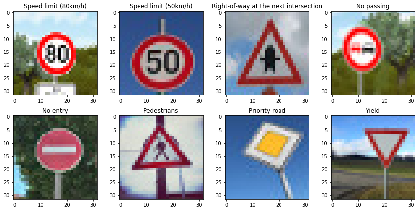

```python
display_web_images(X_web, y_web)
```

```python
#Normalize images and convert to grayscale
X_web_n = list(map(normalize_image, X_web))
X_web_n = np.asarray(X_web_n)

X_web_n = np.asarray(list(map(rgb2gray_pil, X_web_n)))
X_web_n = np.expand_dims(X_web_n,axis=3)
```

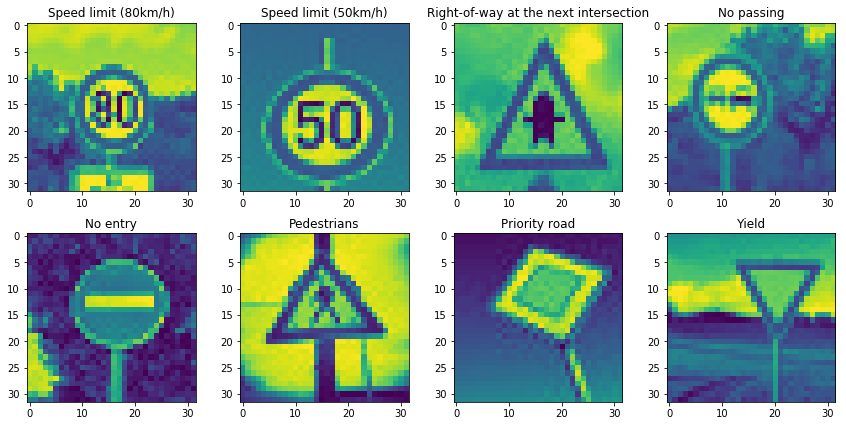

```python
#Pre-processed image
X_web_n_squeezed = X_web_n.squeeze()
display_web_images(X_web_n_squeezed, y_web)
```

### Predict the Sign Type for Each Image

```python
from matplotlib import gridspec

def display_image_predictions(features, labels, predictions, n_predictions):
    plt_fig_width = 6 if n_predictions == 1 else 12

    plt.rcParams['figure.figsize'] = [plt_fig_width,14]
    fig, axes = plt.subplots(nrows=features.shape[0], ncols=2)
    fig.suptitle('Softmax Predictions and Top 5 Probabilities', fontsize=20, y=1.1)

    cols = ['Actual value', 'Prediction']
    for ax, col in zip(axes[0], cols):
        ax.set_title(col, fontsize=14)

    fig.tight_layout()

    margin = 0.05
    ind = np.arange(n_predictions)
    width = (1. - 2. * margin) / n_predictions

    for image_i, (feature, label_id, pred_indicies, pred_values) in enumerate(zip(features, labels, predictions.indices, predictions.values)):
        pred_names = [traffic_name_dict[pred_i] for pred_i in pred_indicies]
        correct_name = traffic_name_dict[label_id]

        axes[image_i][0].imshow(feature)
        axes[image_i][0].set_title(correct_name)
        axes[image_i][0].set_axis_off()

        if n_predictions == 1:
            axes[image_i][1].text(0.3,0.80,pred_names[0],fontsize=12)
            axes[image_i][1].set_axis_off()
        else:
            axes[image_i][1].barh(ind + margin, pred_values[::-1], width)
            axes[image_i][1].set_yticks(ind + margin)
            axes[image_i][1].set_yticklabels(pred_names[::-1])
            axes[image_i][1].set_xticks([0, 0.5, 1.0])
```

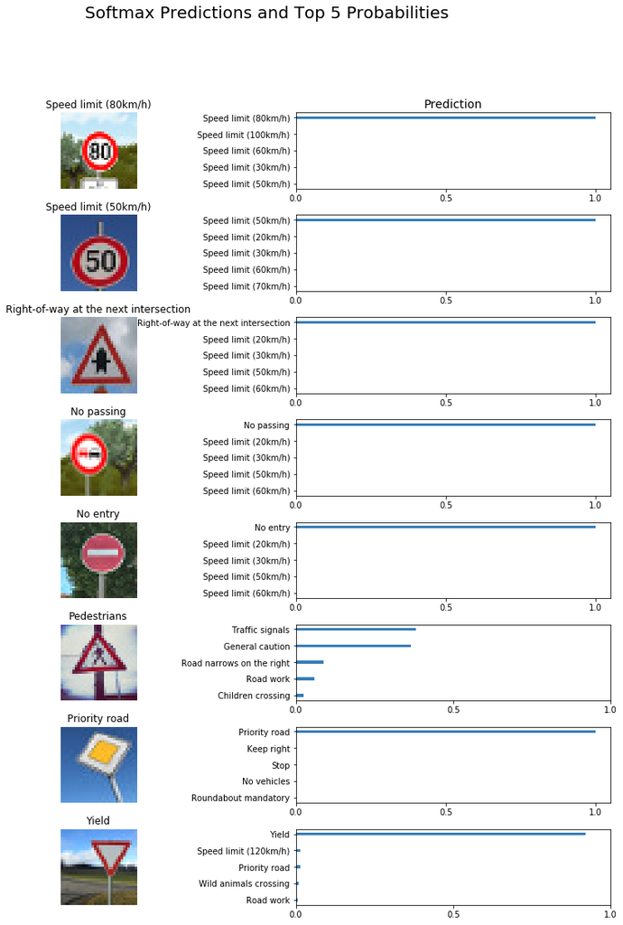

```python
top_n_predictions = 5

with tf.Session() as sess:
    new_saver = tf.train.import_meta_graph(saved_model_path + '.meta')
    new_saver.restore(sess, tf.train.latest_checkpoint('./'))

    graph = tf.get_default_graph()

    loaded_x = graph.get_tensor_by_name('image:0')
    loaded_y = graph.get_tensor_by_name('image_label:0')
    loaded_logits = graph.get_tensor_by_name('logits:0')
    loaded_keep_prob =graph.get_tensor_by_name('keep_prob:0')
    loaded_accuracy = graph.get_tensor_by_name('accuracy:0')

    web_predictions = sess.run(tf.nn.top_k(tf.nn.softmax(loaded_logits), top_n_predictions),
                               feed_dict={loaded_x: X_web_n, loaded_y: y_web, loaded_keep_prob: 1.0})

    display_image_predictions(X_web, y_web, web_predictions, top_n_predictions)

    accuracy = sess.run(loaded_accuracy, feed_dict={loaded_x:X_web_n, loaded_y: y_web, loaded_keep_prob: 1.0})
```

### Analyze Performance

```python
print('Web image identification accuracy: ', accuracy)
```

```
Web image identification accuracy:  0.875
```

## Step 4 (Optional): Visualize the Neural Network's State with Test Images

This Section is not required to complete but acts as an additional excersise for understaning the output of a neural network's weights. While neural networks can be a great learning device they are often referred to as a black box. We can understand what the weights of a neural network look like better by plotting their feature maps. After successfully training your neural network you can see what it's feature maps look like by plotting the output of the network's weight layers in response to a test stimuli image. From these plotted feature maps, it's possible to see what characteristics of an image the network finds interesting. For a sign, maybe the inner network feature maps react with high activation to the sign's boundary outline or to the contrast in the sign's painted symbol.

Provided for you below is the function code that allows you to get the visualization output of any tensorflow weight layer you want. The inputs to the function should be a stimuli image, one used during training or a new one you provided, and then the tensorflow variable name that represents the layer's state during the training process, for instance if you wanted to see what the LeNet lab's feature maps looked like for it's second convolutional layer you could enter conv2 as the tf_activation variable.

For an example of what feature map outputs look like, check out NVIDIA's results in their paper [End-to-End Deep Learning for Self-Driving Cars](https://devblogs.nvidia.com/parallelforall/deep-learning-self-driving-cars/) in the section Visualization of internal CNN State. NVIDIA was able to show that their network's inner weights had high activations to road boundary lines by comparing feature maps from an image with a clear path to one without. Try experimenting with a similar test to show that your trained network's weights are looking for interesting features, whether it's looking at differences in feature maps from images with or without a sign, or even what feature maps look like in a trained network vs a completely untrained one on the same sign image.

[figure not shown]

Your output should look something like this (above)

```python
# image_input: the test image being fed into the network to produce the feature maps
# tf_activation: should be a tf variable name used during your training procedure that represents the calculated state of a specific weight layer
# activation_min/max: can be used to view the activation contrast in more detail, by default matplot sets min and max to the actual min and max values of the output
# plt_num: used to plot out multiple different weight feature map sets on the same block, just extend the plt number for each new feature map entry

def outputFeatureMap(image_input, tf_activation, activation_min=-1, activation_max=-1 ,plt_num=1) :
    # Here make sure to preprocess your image_input in a way your network expects
    # with size, normalization, ect if needed
    # image_input =
    # Note: x should be the same name as your network's tensorflow data placeholder variable
    # If you get an error tf_activation is not defined it may be having trouble accessing the variable from inside a function
    activation = tf_activation.eval(session=sess,feed_dict={x : image_input})
    featuremaps = activation.shape[3]
    featuremaps = featuremaps if featuremaps < 48 else 8
    plt.figure(plt_num, figsize=(15,15))
    for featuremap in range(featuremaps):
        plt.subplot(6,8, featuremap+1) # sets the number of feature maps to show on each row and column
        plt.title('FeatureMap ' + str(featuremap)) # displays the feature map number
        if activation_min != -1 & activation_max != -1:
            plt.imshow(activation[0,:,:, featuremap], interpolation="nearest", vmin =activation_min, vmax=activation_max, cmap="gray")
        elif activation_max != -1:
            plt.imshow(activation[0,:,:, featuremap], interpolation="nearest", vmax=activation_max, cmap="gray")
        elif activation_min !=-1:
            plt.imshow(activation[0,:,:, featuremap], interpolation="nearest", vmin=activation_min, cmap="gray")
        else:
            plt.imshow(activation[0,:,:, featuremap], interpolation="nearest", cmap="gray")
```

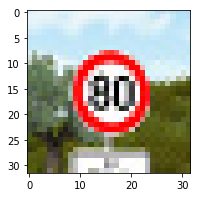

```python
plt.rcParams['figure.figsize'] = [3,3]
plt.imshow(X_web[0])
```

```
Convolution 1
```

[figure not shown]

```python
with tf.Session() as sess:
    new_saver = tf.train.import_meta_graph(saved_model_path + '.meta')
    new_saver.restore(sess, tf.train.latest_checkpoint('./'))
    graph = tf.get_default_graph()
    conv1_tf = graph.get_tensor_by_name('add:0')

    print('Convolution 1')
    outputFeatureMap(X_web_n[:1], conv1_tf)
```

```
Convolution 2
```

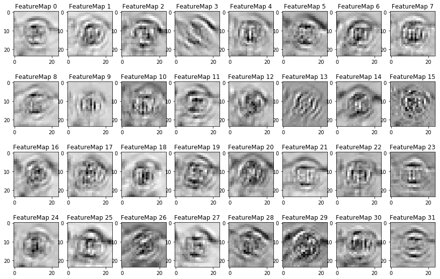

```python
with tf.Session() as sess:
    new_saver = tf.train.import_meta_graph(saved_model_path + '.meta')
    new_saver.restore(sess, tf.train.latest_checkpoint('./'))
    graph = tf.get_default_graph()
    conv2_tf = graph.get_tensor_by_name('add_1:0')

    print('Convolution 2')
    outputFeatureMap(X_web_n[:1], conv2_tf)
```